# Statistika - 2. del

Dani Zugan

2022-06-17

## Naloga 1

```r
data1 <- read.delim("podatki/dn_markerji_pred_po.txt")
```

NGAL

```r
shapiro.test(data1$pred_NGAL)
```

```
##
##  Shapiro-Wilk normality test
##
## data:  data1$pred_NGAL
## W = 0.96847, p-value = 0.1006
```

```r
shapiro.test(data1$po_NGAL)
```

```
##
##  Shapiro-Wilk normality test
##
## data:  data1$po_NGAL
## W = 0.94828, p-value = 0.009427
```

```r
wilcox.test(data1$pred_NGAL,data1$po_NGAL, paired = TRUE)
```

```
##
##  Wilcoxon signed rank test with continuity correction
##
## data:  data1$pred_NGAL and data1$po_NGAL
## V = 2, p-value = 3.967e-12
## alternative hypothesis: true location shift is not equal to 0
```

Za NGAL so statisticno znacilne razlike pred in po operaciji (p < 0.05).

CYS

```r
shapiro.test(data1$pred_CYS)
```

```
##
##  Shapiro-Wilk normality test
##
## data:  data1$pred_CYS
## W = 0.96869, p-value = 0.1034
```

```r
shapiro.test(data1$po_CYS)
```

```
##
##  Shapiro-Wilk normality test
##
## data:  data1$po_CYS
## W = 0.91644, p-value = 0.000354
```

```r
wilcox.test(data1$pred_CYS, data1$po_CYS, paired = TRUE)
```

```
##
##  Wilcoxon signed rank test with continuity correction
##
## data:  data1$pred_CYS and data1$po_CYS
## V = 1286, p-value = 0.1006
## alternative hypothesis: true location shift is not equal to 0
```

Za CYS ni statisticno znacilne razlike pred in po operaciji (p > 0.05).

KREA

```r
shapiro.test(data1$pred_KREA)
```

```
##
##  Shapiro-Wilk normality test
##
## data:  data1$pred_KREA
## W = 0.96629, p-value = 0.07747
```

```r
shapiro.test(data1$po_KREA)
```

```
##
##  Shapiro-Wilk normality test
##
## data:  data1$po_KREA
## W = 0.9637, p-value = 0.05677
```

```r
t.test(data1$pred_KREA, data1$po_KREA, paired = TRUE)
```

```
##
##  Paired t-test
##
## data:  data1$pred_KREA and data1$po_KREA
## t = 2.7897, df = 63, p-value = 0.00697
## alternative hypothesis: true mean difference is not equal to 0
## 95 percent confidence interval:
##  1.090372 6.597128
## sample estimates:
## mean difference
##         3.84375
```

Za KREA so statisticno znacilne razlike pred in po operaciji (p < 0.05).

## Naloga 2

```r
data2 <- as.table(rbind(c(25, 6, 17, 13), c(17, 16, 15, 6),
                        c(18, 4, 18, 10), c(10, 8, 11, 20)))

data2
```

```
##    A  B  C  D
## A 25  6 17 13
## B 17 16 15  6
## C 18  4 18 10
## D 10  8 11 20
```

```r
chisq.test(data2)
```

```
##
##  Pearson's Chi-squared test
##
## data:  data2
## X-squared = 25.555, df = 9, p-value = 0.002415
```

p-vrednost je manjsa od 0.05, kar pomeni, da ne moremo trditi da ocene niso povezane med seboj.

## Naloga 3

```r
data3 <- read_excel("podatki/zdravljenje.xlsx")
```

### i

```r
data3spol <- data3 %>%
  group_by(zdravilo, spol) %>%
  summarise(pov = mean(marker), std = sd(marker))
data3zdravilo <- data3 %>%
  group_by(zdravilo) %>%
  summarise(pov = mean(marker), std = sd(marker))
```

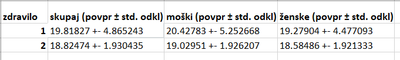

Tabela i

### ii

```r
data3z1 <- data3[data3$zdravilo==1,]
data3z2 <- data3[data3$zdravilo==2,]

shapiro.test(data3z1$marker)
```

```
##
##  Shapiro-Wilk normality test
##
## data:  data3z1$marker
## W = 0.9804, p-value = 0.1516
```

```r
shapiro.test(data3z2$marker)
```

```
##
##  Shapiro-Wilk normality test
##
## data:  data3z2$marker
## W = 0.99062, p-value = 0.411
```

Lahko sklepamo, da so meritve so normalno porazdeljene, saj sta obe p-vrednosti vecji od 0.05

### iii

```r
t.test(data3z1$marker, data3z2$marker)
```

```
##
##  Welch Two Sample t-test
##
## data:  data3z1$marker and data3z2$marker
## t = 1.9262, df = 116.92, p-value = 0.05651
## alternative hypothesis: true difference in means is not equal to 0
## 95 percent confidence interval:
##  -0.02800164  2.01505857
## sample estimates:
## mean of x mean of y
##  19.81827  18.82474
```

Med zdraviloma ni statisticno znacilne razlike (p > 0.05). Nicte hipoteze ne moremo zavrniti in s tem ne moremo trditi, da ima vrsta zdravila vpliv na markerje.

### b

```r
data3b <- data3 %>%
  group_by(zdravilo, spol) %>%
  summarise(stevilo = n()) %>%
  mutate(procent = (stevilo / sum(stevilo))*100)
knitr::kable(data3b, format = "markdown")
```

| zdravilo | spol | stevilo | procent |
| --- | --- | --- | --- |
| 1 | M | 46 | 46.93878 |
| 1 | Z | 52 | 53.06122 |
| 2 | M | 82 | 53.94737 |
| 2 | Z | 70 | 46.05263 |

Iz tabele lahko vidimo, da sta deleza mosk in zensk pri zdravilih razlicna.

```r
data3.1Z <- data3z1$marker[data3z1$spol=="Z"]
data3.1M <- data3z1$marker[data3z1$spol=="M"]
data3.2Z <- data3z2$marker[data3z2$spol=="Z"]
data3.2M <- data3z2$marker[data3z2$spol=="M"]
```

```r
shapiro.test(data3.1Z)
```

```
##
##  Shapiro-Wilk normality test
##
## data:  data3.1Z
## W = 0.97095, p-value = 0.2316
```

```r
shapiro.test(data3.1M)
```

```
##
##  Shapiro-Wilk normality test
##
## data:  data3.1M
## W = 0.97484, p-value = 0.4135
```

```r
shapiro.test(data3.2Z)
```

```
##
##  Shapiro-Wilk normality test
##
## data:  data3.2Z
## W = 0.97609, p-value = 0.2004
```

```r
shapiro.test(data3.2M)
```

```
##
##  Shapiro-Wilk normality test
##
## data:  data3.2M
## W = 0.97894, p-value = 0.1968
```

Meritve so normalno porazdeljene tudi glede na spol.

```r
t.test(data3.1Z, data3.1M)
```

```
##
##  Welch Two Sample t-test
##
## data:  data3.1Z and data3.1M
## t = -1.1573, df = 88.994, p-value = 0.2502
## alternative hypothesis: true difference in means is not equal to 0
## 95 percent confidence interval:
##  -3.1210722  0.8234969
## sample estimates:
## mean of x mean of y
##  19.27904  20.42783
```

```r
t.test(data3.2Z, data3.2M)
```

```
##
##  Welch Two Sample t-test
##
## data:  data3.2Z and data3.2M
## t = -1.4205, df = 146.39, p-value = 0.1576
## alternative hypothesis: true difference in means is not equal to 0
## 95 percent confidence interval:
##  -1.0632823  0.1739722
## sample estimates:
## mean of x mean of y
##  18.58486  19.02951
```

Obe p-vrednosti sta vecji od 0.05 torej ni statisticno znacilno razlike med spoloma za obe zdravili.

## Naloga 4

```r
x <- c(60,63,65,70,70,70,80,90,80,80,85,89,90,90,90,90,94,100,100,100)
y <- c(1,0,1,2,5,1,4,6,2,3,5,4,6,8,4,5,7,9,7,6)
data4 <- data.frame(x = x,y = y)
```

### a.

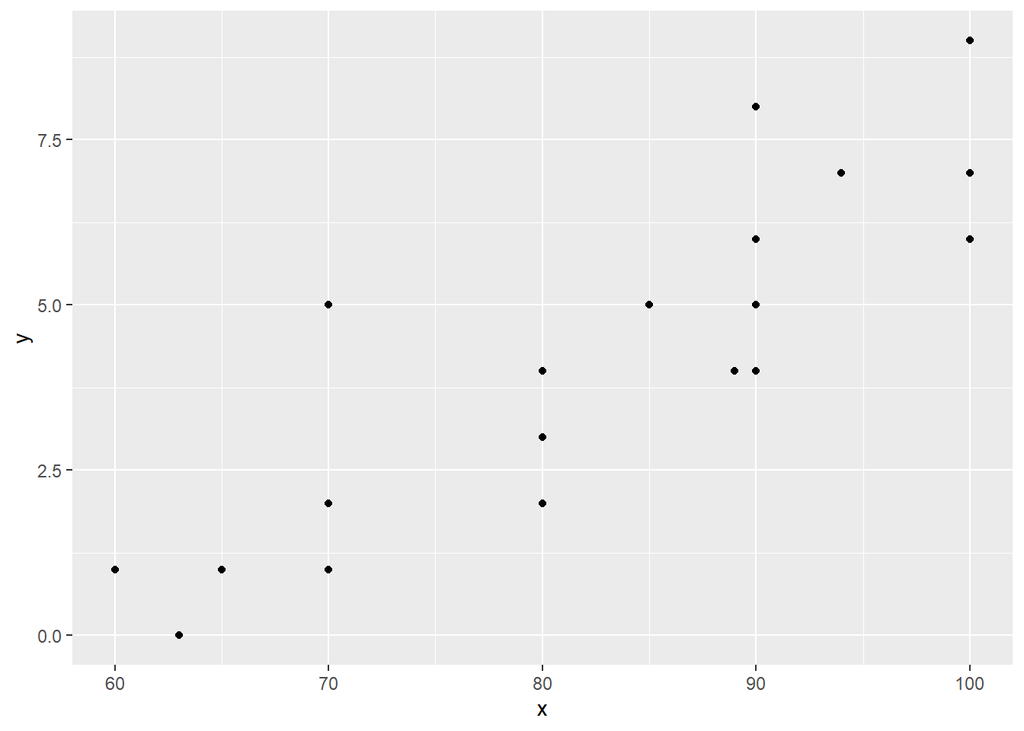

```r
ggplot(data = data4)+
  geom_point(aes(x = x, y = y))
```

Na podlagi diagrama lahko upravičeno sklepamo, da je linearna regresija primeren model za modeliranje odvisnosti med y in x.

### b.

```r
linearMod4 <- lm(y ~ x, data4)
summary(linearMod4)
```

```
##
## Call:
## lm(formula = y ~ x, data = data4)
##
## Residuals:
##     Min      1Q  Median      3Q     Max
## -1.8120 -0.9040 -0.1333  0.5023  2.9310
##
## Coefficients:
##              Estimate Std. Error t value Pr(>|t|)
## (Intercept) -10.13154    1.99490  -5.079 7.83e-05 ***
## x             0.17429    0.02383   7.314 8.57e-07 ***
## ---
## Signif. codes:  0 '***' 0.001 '**' 0.01 '*' 0.05 '.' 0.1 ' ' 1
##
## Residual standard error: 1.318 on 18 degrees of freedom
## Multiple R-squared:  0.7483, Adjusted R-squared:  0.7343
## F-statistic:  53.5 on 1 and 18 DF,  p-value: 8.567e-07
```

### c.

```r
napoved.4c <- -10.13154 + 0.17429*85
napoved.4c
```

```
## [1] 4.68311
```

### d.

```r
summary(linearMod4)
```

```
##
## Call:
## lm(formula = y ~ x, data = data4)
##
## Residuals:
##     Min      1Q  Median      3Q     Max
## -1.8120 -0.9040 -0.1333  0.5023  2.9310
##
## Coefficients:
##              Estimate Std. Error t value Pr(>|t|)
## (Intercept) -10.13154    1.99490  -5.079 7.83e-05 ***
## x             0.17429    0.02383   7.314 8.57e-07 ***
## ---
## Signif. codes:  0 '***' 0.001 '**' 0.01 '*' 0.05 '.' 0.1 ' ' 1
##
## Residual standard error: 1.318 on 18 degrees of freedom
## Multiple R-squared:  0.7483, Adjusted R-squared:  0.7343
## F-statistic:  53.5 on 1 and 18 DF,  p-value: 8.567e-07
```

p-vrednost modela je 8.567e-07, konstanta (intercept) ima p-vrednost 7.83e-05, beta koeficient ima p-vrednost 8.57e-07. Vse vrednosti so statisticno znacilne (p < 0.05).

### e.

```r
summary(linearMod4)
```

```
##
## Call:
## lm(formula = y ~ x, data = data4)
##
## Residuals:
##     Min      1Q  Median      3Q     Max
## -1.8120 -0.9040 -0.1333  0.5023  2.9310
##
## Coefficients:
##              Estimate Std. Error t value Pr(>|t|)
## (Intercept) -10.13154    1.99490  -5.079 7.83e-05 ***
## x             0.17429    0.02383   7.314 8.57e-07 ***
## ---
## Signif. codes:  0 '***' 0.001 '**' 0.01 '*' 0.05 '.' 0.1 ' ' 1
##
## Residual standard error: 1.318 on 18 degrees of freedom
## Multiple R-squared:  0.7483, Adjusted R-squared:  0.7343
## F-statistic:  53.5 on 1 and 18 DF,  p-value: 8.567e-07
```

Tak model pokrije 0.7343 variance (Adjusted R-squared).

### f.

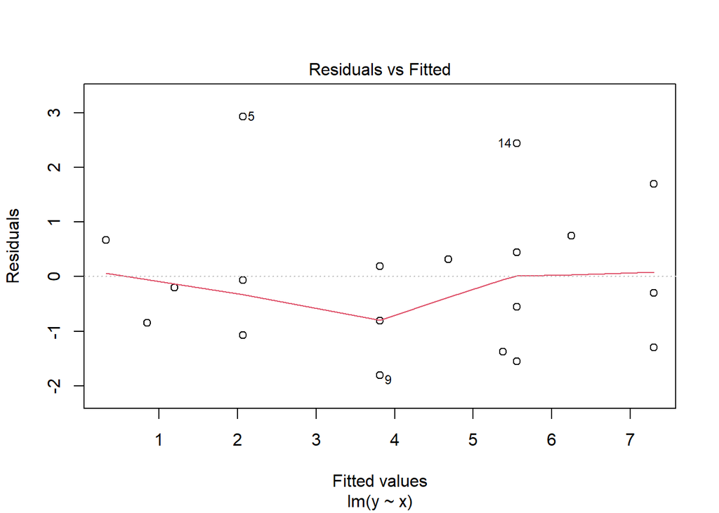

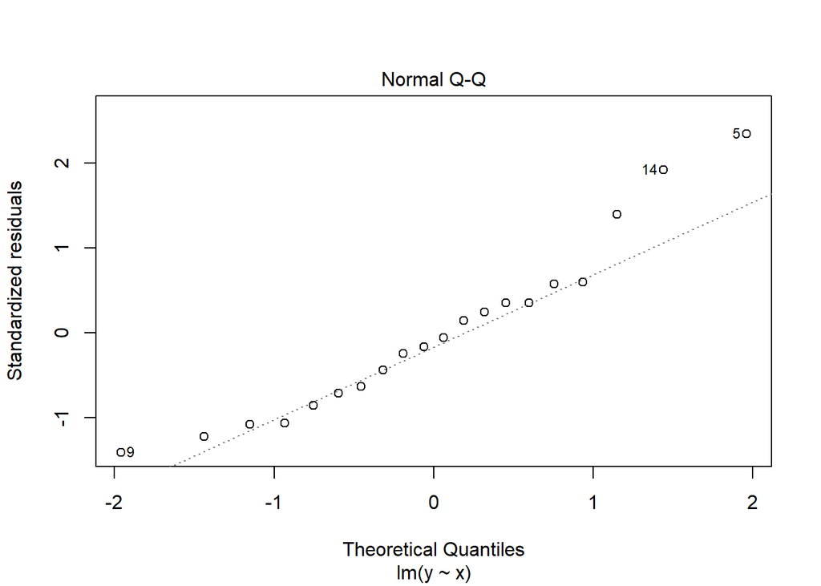

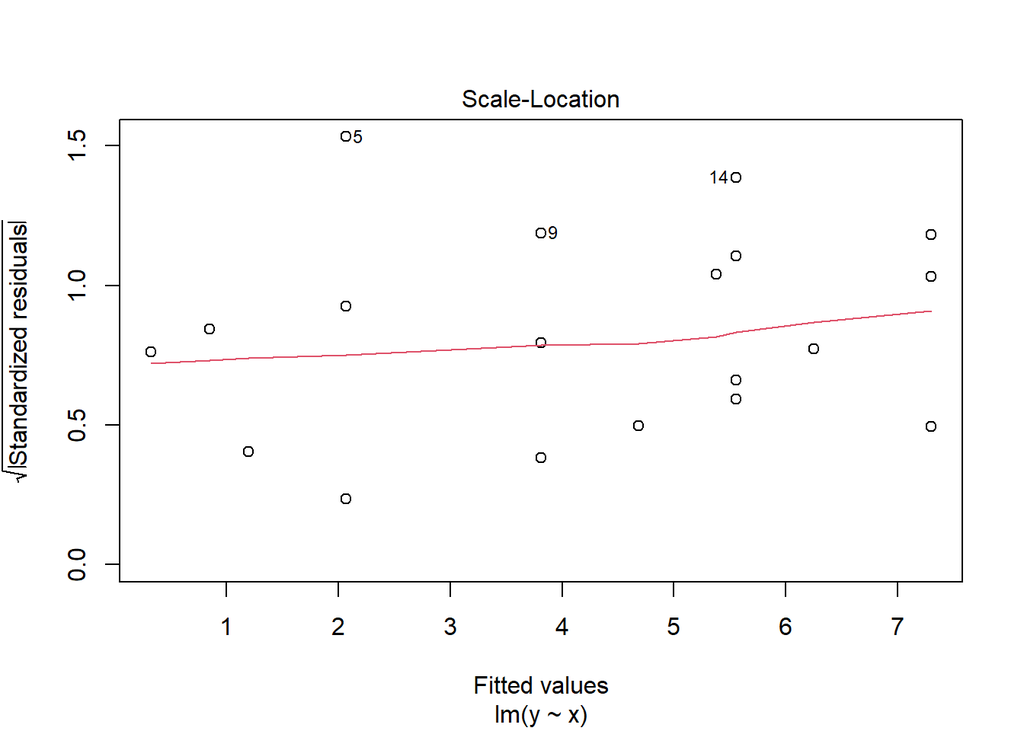

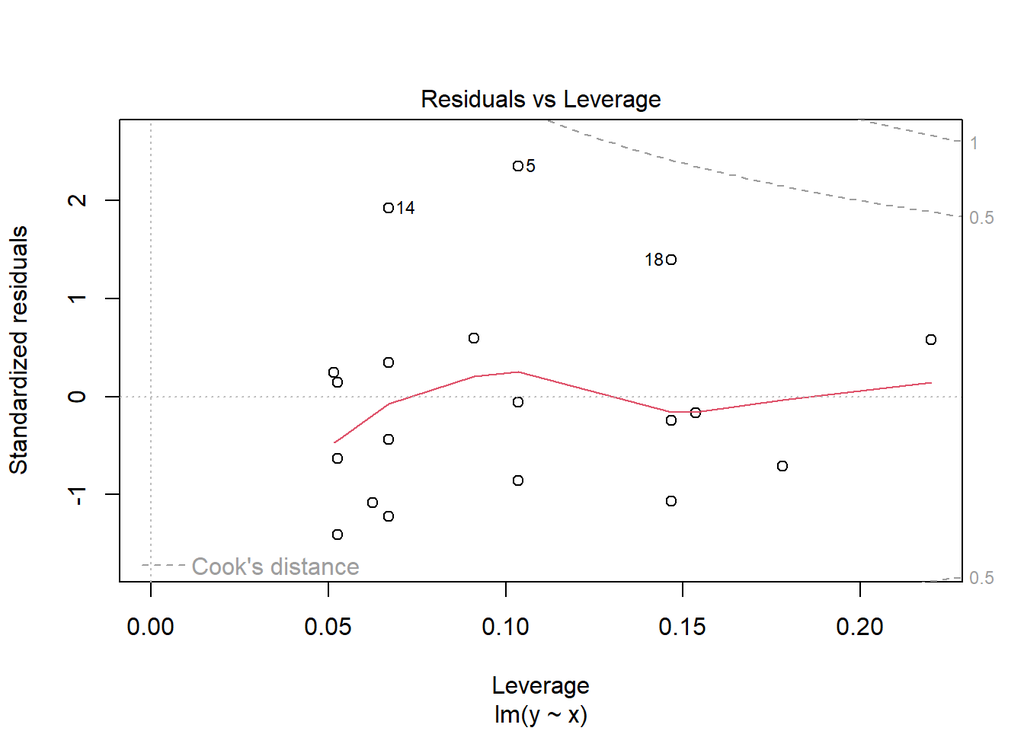

```r
plot(linearMod4)
```

V drugem grafu lahko vidimo, da so meritve normalno porazdeljene (razen treh).

V cetrtem grafu lahko vidimo, da so meritve 14, 5 in 18 najbolj vplivne na oceno parametrov modela.

### g.

```r
data4.out <- data4[-c(14,5),]
linearMod4out <- lm(y ~ x, data4.out)
summary(linearMod4out)
```

```
##
## Call:
## lm(formula = y ~ x, data = data4.out)
##
## Residuals:
##     Min      1Q  Median      3Q     Max
## -1.4897 -0.6255  0.0556  0.6688  1.8725
##
## Coefficients:
##              Estimate Std. Error t value Pr(>|t|)
## (Intercept) -11.06146    1.52304  -7.263  1.9e-06 ***
## x             0.18189    0.01812  10.038  2.6e-08 ***
## ---
## Signif. codes:  0 '***' 0.001 '**' 0.01 '*' 0.05 '.' 0.1 ' ' 1
##
## Residual standard error: 0.9659 on 16 degrees of freedom
## Multiple R-squared:  0.863,  Adjusted R-squared:  0.8544
## F-statistic: 100.8 on 1 and 16 DF,  p-value: 2.604e-08
```

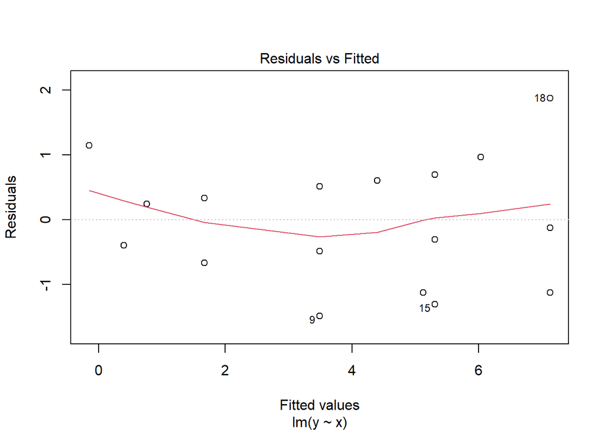

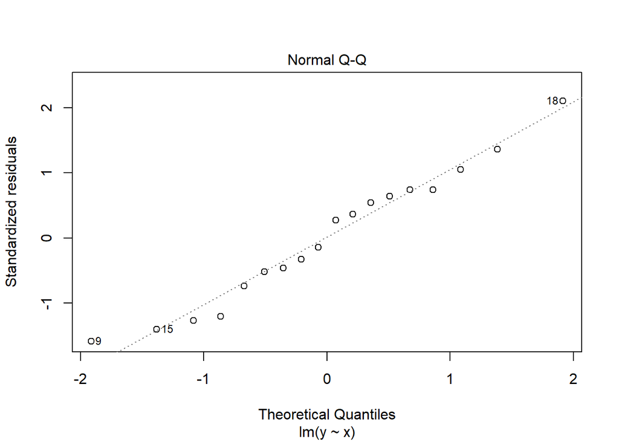

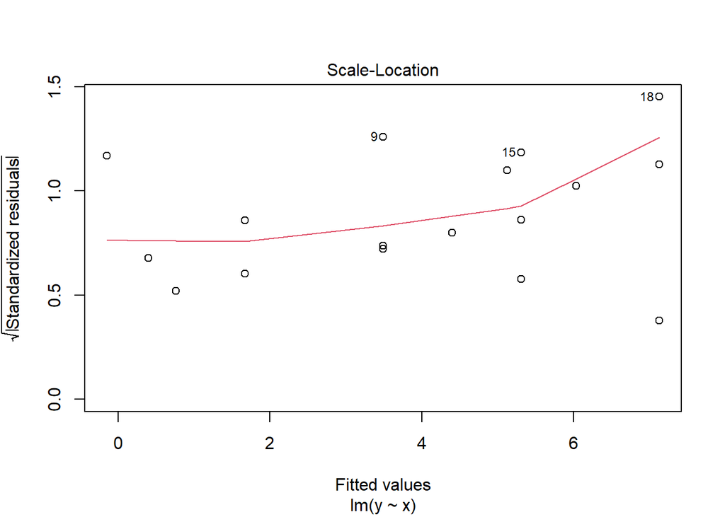

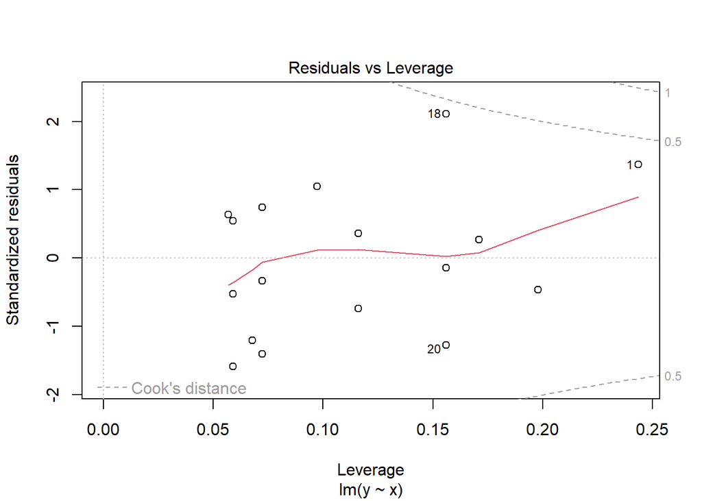

```r
plot(linearMod4out)
```

```r
AIC(linearMod4,linearMod4out)
```

```
##               df      AIC
## linearMod4     3 71.69382
## linearMod4out  3 53.71327
```

Drugi model je boljsi, saj ima manjsi AIC.

## Naloga 5

```r
data5 <- read.delim("podatki/dn_kreatinin_akin.txt")
```

```r
gMod5 <- glm(AKIN ~ Kreatinin, data = data5, family=binomial)
summary(gMod5)
```

```
##
## Call:
## glm(formula = AKIN ~ Kreatinin, family = binomial, data = data5)
##
## Deviance Residuals:
##     Min       1Q   Median       3Q      Max
## -1.4559  -0.4684  -0.2709   0.1781   3.2669
##
## Coefficients:
##              Estimate Std. Error z value Pr(>|z|)
## (Intercept) -11.51850    2.78839  -4.131 3.61e-05 ***
## Kreatinin     0.11048    0.02846   3.882 0.000104 ***
## ---
## Signif. codes:  0 '***' 0.001 '**' 0.01 '*' 0.05 '.' 0.1 ' ' 1
##
## (Dispersion parameter for binomial family taken to be 1)
##
##     Null deviance: 82.565  on 65  degrees of freedom
## Residual deviance: 39.944  on 64  degrees of freedom
## AIC: 43.944
##
## Number of Fisher Scoring iterations: 6
```

```r
p_predict = predict(gMod5, data5, type = "response")
mask = (p_predict >= 0.5)
min(data5$Kreatinin[mask])
```

```
## [1] 109
```

Mejna vrednost kreatinina, pri katerem pride do akutnega vnetja ledvic je 109.

## Naloga 6

```r
data6 <- read.delim("podatki/dn_cars.txt", sep = " ")
```

### a.

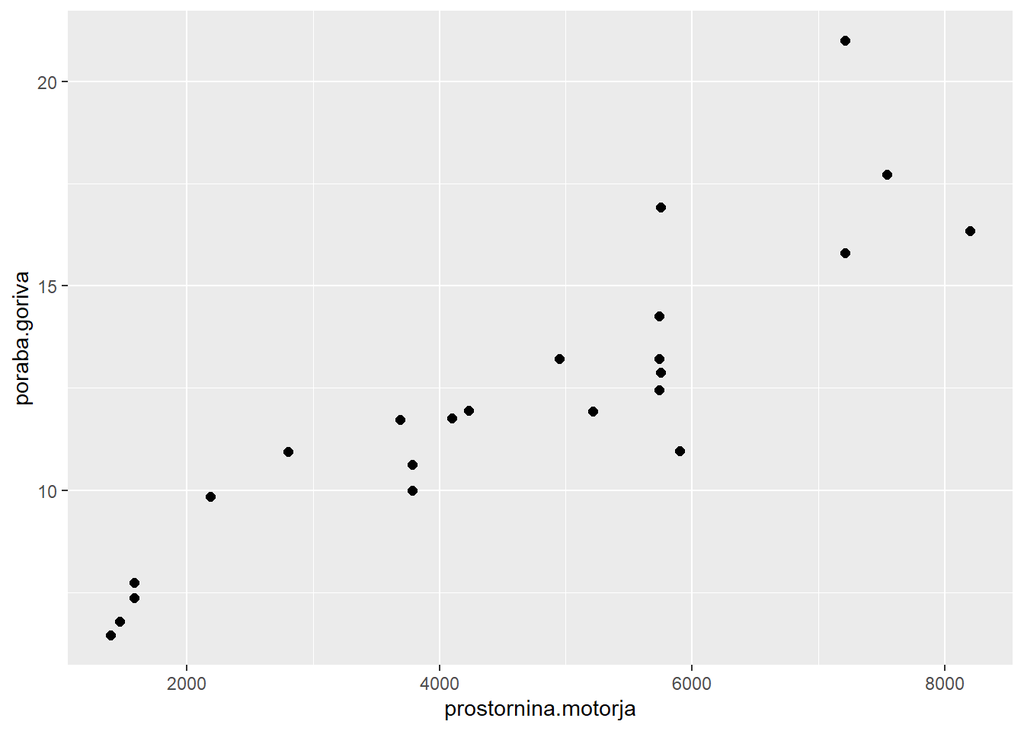

```r
ggplot(data = data6)+
  geom_point(aes(x = prostornina.motorja, y=poraba.goriva), size = 2)
```

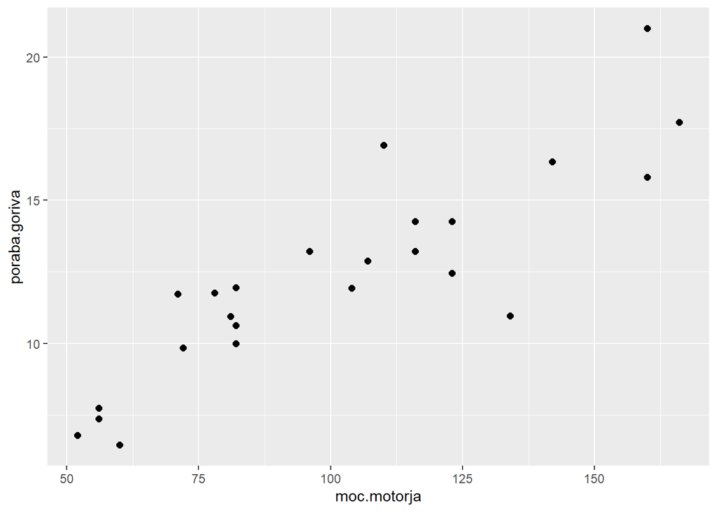

```r
ggplot(data = data6)+
  geom_point(aes(x = moc.motorja, y=poraba.goriva), size = 2)
```

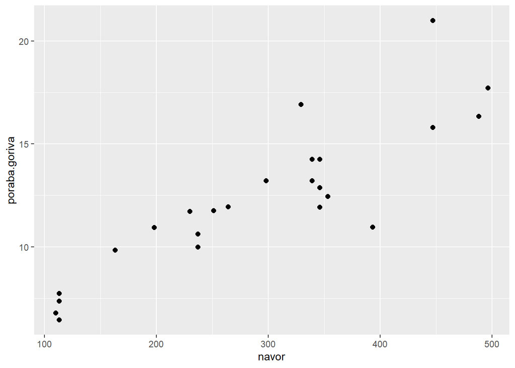

```r
ggplot(data = data6)+
  geom_point(aes(x = navor, y=poraba.goriva), size = 2)
```

Na podlagi grafov, lahko sklepamo, da poraba goriva narašča z naraščanjem vseh treh opisnih spremenljivk (prostornina, moc, navor).

### b.

```r
multiMod6 <- lm(poraba.goriva ~ prostornina.motorja + moc.motorja + navor, data = data6)
summary(multiMod6)
```

```
##
## Call:
## lm(formula = poraba.goriva ~ prostornina.motorja + moc.motorja +
##     navor, data = data6)
##
## Residuals:
##     Min      1Q  Median      3Q     Max
## -2.7845 -0.9114 -0.3412  1.0121  3.7592
##
## Coefficients:
##                      Estimate Std. Error t value Pr(>|t|)
## (Intercept)          4.396758   1.137033   3.867  0.00096 ***
## prostornina.motorja  0.003402   0.001401   2.429  0.02469 *
## moc.motorja          0.067591   0.039974   1.691  0.10639
## navor               -0.050347   0.029924  -1.682  0.10803
## ---
## Signif. codes:  0 '***' 0.001 '**' 0.01 '*' 0.05 '.' 0.1 ' ' 1
##
## Residual standard error: 1.575 on 20 degrees of freedom
## Multiple R-squared:  0.8309, Adjusted R-squared:  0.8055
## F-statistic: 32.76 on 3 and 20 DF,  p-value: 6.509e-08
```

```r
multiMod6.2 = step(multiMod6, direction = "both")
```

```
## Start:  AIC=25.42
## poraba.goriva ~ prostornina.motorja + moc.motorja + navor
##
##                       Df Sum of Sq    RSS    AIC
## <none>                             49.603 25.424
## - navor                1    7.0205 56.623 26.601
## - moc.motorja          1    7.0908 56.693 26.631
## - prostornina.motorja  1   14.6328 64.235 29.628
```

```r
summary(multiMod6.2)
```

```
##
## Call:
## lm(formula = poraba.goriva ~ prostornina.motorja + moc.motorja +
##     navor, data = data6)
##
## Residuals:
##     Min      1Q  Median      3Q     Max
## -2.7845 -0.9114 -0.3412  1.0121  3.7592
##
## Coefficients:
##                      Estimate Std. Error t value Pr(>|t|)
## (Intercept)          4.396758   1.137033   3.867  0.00096 ***
## prostornina.motorja  0.003402   0.001401   2.429  0.02469 *
## moc.motorja          0.067591   0.039974   1.691  0.10639
## navor               -0.050347   0.029924  -1.682  0.10803
## ---
## Signif. codes:  0 '***' 0.001 '**' 0.01 '*' 0.05 '.' 0.1 ' ' 1
##
## Residual standard error: 1.575 on 20 degrees of freedom
## Multiple R-squared:  0.8309, Adjusted R-squared:  0.8055
## F-statistic: 32.76 on 3 and 20 DF,  p-value: 6.509e-08
```

```r
multiMod6.3 <- lm(poraba.goriva ~ prostornina.motorja, data = data6)
summary(multiMod6.3)
```

```
##
## Call:
## lm(formula = poraba.goriva ~ prostornina.motorja, data = data6)
##
## Residuals:
##     Min      1Q  Median      3Q     Max
## -3.3697 -0.8910  0.0118  0.4934  4.6111
##
## Coefficients:
##                      Estimate Std. Error t value Pr(>|t|)
## (Intercept)         5.0388756  0.8413144   5.989 5.00e-06 ***
## prostornina.motorja 0.0015740  0.0001667   9.440 3.41e-09 ***
## ---
## Signif. codes:  0 '***' 0.001 '**' 0.01 '*' 0.05 '.' 0.1 ' ' 1
##
## Residual standard error: 1.625 on 22 degrees of freedom
## Multiple R-squared:  0.802,  Adjusted R-squared:  0.793
## F-statistic: 89.11 on 1 and 22 DF,  p-value: 3.409e-09
```

```r
AIC(multiMod6, multiMod6.3)
```

```
##             df      AIC
## multiMod6    5 95.53281
## multiMod6.3  3 95.31892
```

Oba modela sta statisticno znacilna (p < 0.05). Pri prvem modelu moc in navor nista statisticno znacilna, zato sem ju izlocil.

Minimalni model(2.) je boljsi, saj ima le eno spremenljivko (tudi manjsi AIC).

### i

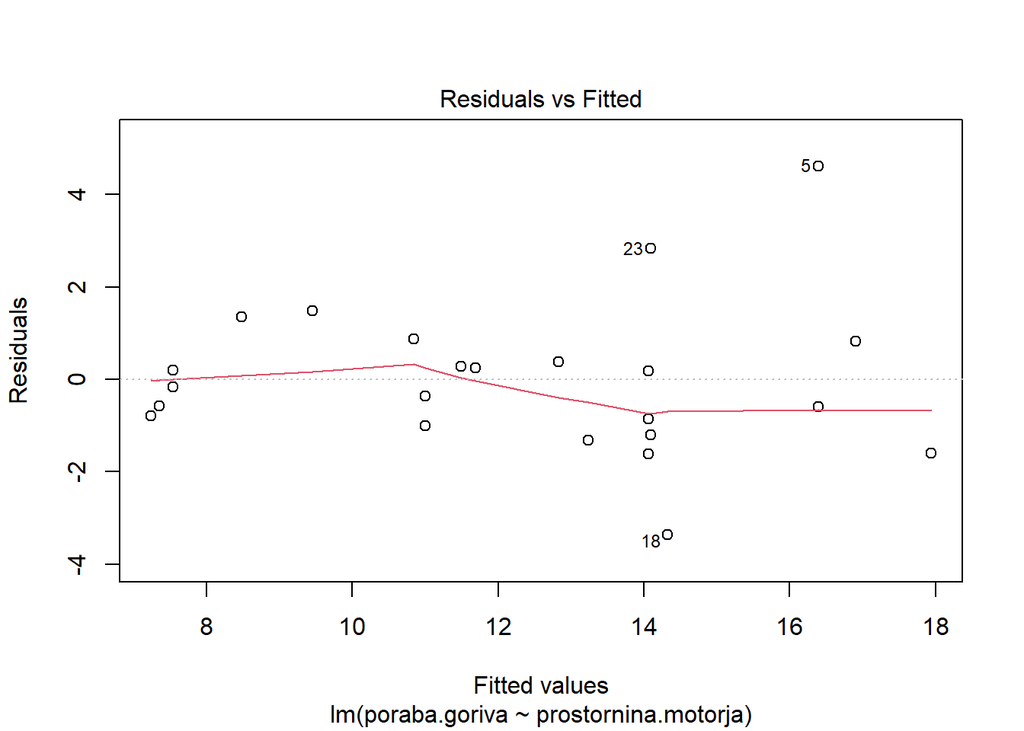

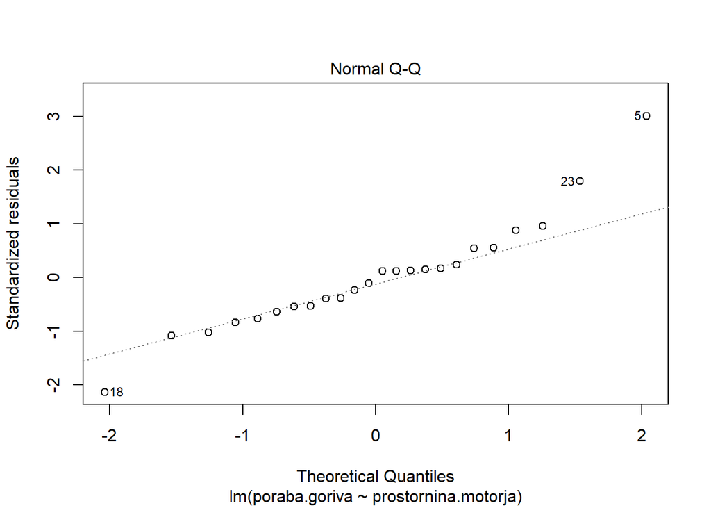

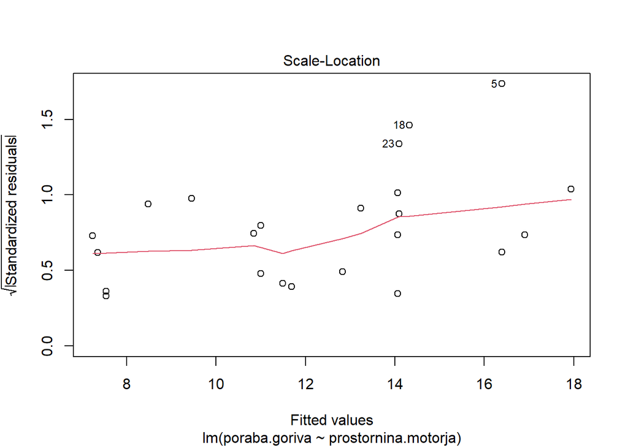

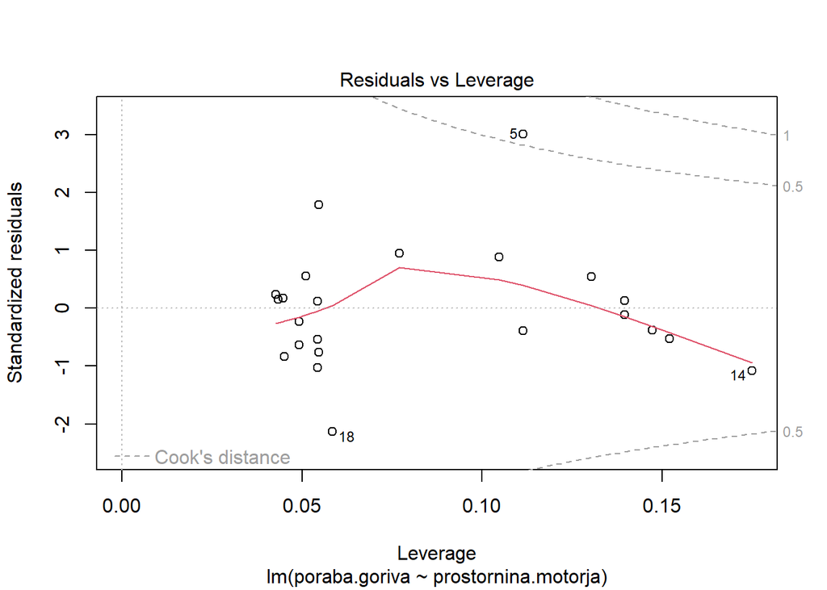

```r
plot(multiMod6.3)
```

Na podlagi prvega grafa vidimo, da imamo heteroskedastičnost.

Na podlagi drugega grafa vidimo, da imamo normalno porazdelitev (18, 23, 5 izstopajo).

Na podlagi cetrtega grafa vidimo, da 5 najbolj izstopa.

### d.

```r
data6.out <- data6[-c(18,5),]
multiMod6.out <- lm(poraba.goriva ~ prostornina.motorja, data=data6.out)
summary(multiMod6.out)
```

```
##
## Call:
## lm(formula = poraba.goriva ~ prostornina.motorja, data = data6.out)
##
## Residuals:
##     Min      1Q  Median      3Q     Max
## -1.4495 -0.9557 -0.1465  0.4540  3.0020
##
## Coefficients:
##                      Estimate Std. Error t value Pr(>|t|)
## (Intercept)         5.3886573  0.5844881   9.219 1.22e-08 ***
## prostornina.motorja 0.0014829  0.0001197  12.385 7.77e-11 ***
## ---
## Signif. codes:  0 '***' 0.001 '**' 0.01 '*' 0.05 '.' 0.1 ' ' 1
##
## Residual standard error: 1.111 on 20 degrees of freedom
## Multiple R-squared:  0.8847, Adjusted R-squared:  0.8789
## F-statistic: 153.4 on 1 and 20 DF,  p-value: 7.767e-11
```

```r
AIC(multiMod6.out, multiMod6.3)
```

```
##               df      AIC
## multiMod6.out  3 70.96097
## multiMod6.3    3 95.31892
```

Vidimo, da je model brez dveh meritev boljsi, saj ima nizjo p-vrednost in AIC.

## Naloga 7

```r
data7 <- read_excel("podatki/titanic3.xls")
table(data7$survived, data7$age)
```

```
##
##     0.1667 0.3333 0.4167 0.6667 0.75 0.8333 0.9167  1  2  3  4  5  6  7  8  9
##   0      0      1      0      0    1      0      0  3  8  2  3  1  3  2  2  6
##   1      1      0      1      1    2      3      2  7  4  5  7  4  3  2  4  4
##
##     10 11 11.5 12 13 14 14.5 15 16 17 18 18.5 19 20 20.5 21 22 22.5 23 23.5 24
##   0  4  3    1  0  2  4    2  1 11 13 25    3 18 15    1 30 23    1 16    1 25
##   1  0  1    0  3  3  4    0  5  8  7 14    0 11  8    0 11 20    0 10    0 22
##
##     24.5 25 26 26.5 27 28 28.5 29 30 30.5 31 32 32.5 33 34 34.5 35 36 36.5 37
##   0    1 23 19    1 17 24    3 17 25    2 11 13    3 12 10    2 10 17    1  7
##   1    0 11 11    0 13  8    0 13 15    0 12 11    1  9  6    0 13 14    1  2
##
##     38 38.5 39 40 40.5 41 42 43 44 45 45.5 46 47 48 49 50 51 52 53 54 55 55.5
##   0  8    1 12 12    3  9 12  6  7  7    2  6 11  4  4  9  5  3  0  5  4    1
##   1  6    0  8  6    0  2  6  3  3 14    0  0  3 10  5  6  3  3  4  5  4    0
##
##     56 57 58 59 60 60.5 61 62 63 64 65 66 67 70 70.5 71 74 76 80
##   0  2  5  2  2  3    1  5  3  2  3  3  1  1  2    1  2  1  0  0
##   1  2  0  4  1  4    0  0  2  2  2  0  0  0  0    0  0  0  1  1
```

```r
table(data7$survived, data7$sex)
```

```
##
##     female male
##   0    127  682
##   1    339  161
```

```r
table(data7$survived, data7$pclass)
```

```
##
##       1   2   3
##   0 123 158 528
##   1 200 119 181
```

```r
table(data7$survived, data7$alone)
```

```
##
##       0   1
##   0 258 551
##   1 261 239
```

### c.

```r
logMod <- glm(survived ~ age + sex + pclass + alone, data = data7, family = binomial)
summary(logMod)
```

```
##
## Call:
## glm(formula = survived ~ age + sex + pclass + alone, family = binomial,
##     data = data7)
##
## Deviance Residuals:
##     Min       1Q   Median       3Q      Max
## -2.6172  -0.7177  -0.4292   0.6546   2.4075
##
## Coefficients:
##              Estimate Std. Error z value Pr(>|z|)
## (Intercept)  4.585871   0.405830  11.300  < 2e-16 ***
## age         -0.033535   0.006376  -5.260 1.44e-07 ***
## sexmale     -2.485280   0.170297 -14.594  < 2e-16 ***
## pclass      -1.126975   0.113448  -9.934  < 2e-16 ***
## alone       -0.052029   0.165375  -0.315    0.753
## ---
## Signif. codes:  0 '***' 0.001 '**' 0.01 '*' 0.05 '.' 0.1 ' ' 1
##
## (Dispersion parameter for binomial family taken to be 1)
##
##     Null deviance: 1414.62  on 1045  degrees of freedom
## Residual deviance:  982.93  on 1041  degrees of freedom
##   (263 observations deleted due to missingness)
## AIC: 992.93
##
## Number of Fisher Scoring iterations: 4
```

Model lahko napoveduje kaksna je verjetnost, da bo oseba potonila na podlagi spola, starosti, razreda, nacinom potovanja. Starost, spol in razred statisticno znacilno vplivajo na napoved. Na podlagi modela ima tako moski za 2.49 vecjo moznost, da potone, vsako leto vec pomeni za 0.03 vecjo moznost, da oseba potone, vsak razred vec pomeni 1.13 vecjo moznost, da oseba potone.

```r
set.seed(123)
training.set = createDataPartition(c(1:nrow(data7)), p = 0.7, list = FALSE)
train.data <- data7[training.set, ]
test.data <- data7[-training.set, ]

logMod.test <- glm(survived ~ age + sex + pclass + alone, data = train.data, family = binomial)
summary(logMod.test)
```

```
##
## Call:
## glm(formula = survived ~ age + sex + pclass + alone, family = binomial,
##     data = train.data)
##
## Deviance Residuals:
##     Min       1Q   Median       3Q      Max
## -2.2871  -0.7054  -0.4394   0.6673   2.4036
##
## Coefficients:
##              Estimate Std. Error z value Pr(>|z|)
## (Intercept)  4.360186   0.481638   9.053  < 2e-16 ***
## age         -0.031913   0.007736  -4.125  3.7e-05 ***
## sexmale     -2.427915   0.200345 -12.119  < 2e-16 ***
## pclass      -1.022963   0.132183  -7.739  1.0e-14 ***
## alone       -0.258789   0.194641  -1.330    0.184
## ---
## Signif. codes:  0 '***' 0.001 '**' 0.01 '*' 0.05 '.' 0.1 ' ' 1
##
## (Dispersion parameter for binomial family taken to be 1)
##
##     Null deviance: 981.27  on 731  degrees of freedom
## Residual deviance: 693.70  on 727  degrees of freedom
##   (185 observations deleted due to missingness)
## AIC: 703.7
##
## Number of Fisher Scoring iterations: 4
```

```r
verjetnost = predict(logMod.test, newdata = test.data, type = "response")
roc_dat = roc(test.data$survived, verjetnost)
roc_dat
```

```
##
## Call:
## roc.default(response = test.data$survived, predictor = verjetnost)
##
## Data: verjetnost in 175 controls (test.data$survived 0) < 139 cases (test.data$survived 1).
## Area under the curve: 0.8498
```

## d

```r
logMod2 = step(logMod, direction = "both")
```

```
## Start:  AIC=992.93
## survived ~ age + sex + pclass + alone
##
##          Df Deviance     AIC
## - alone   1   983.02  991.02
## <none>        982.93  992.93
## - age     1  1012.17 1020.17
## - pclass  1  1095.80 1103.80
## - sex     1  1240.05 1248.05
##
## Step:  AIC=991.02
## survived ~ age + sex + pclass
##
##          Df Deviance     AIC
## <none>        983.02  991.02
## + alone   1   982.93  992.93
## - age     1  1013.85 1019.85
## - pclass  1  1101.34 1107.34
## - sex     1  1256.18 1262.18
```

```r
summary(logMod2)
```

```
##
## Call:
## glm(formula = survived ~ age + sex + pclass, family = binomial,
##     data = data7)
##
## Deviance Residuals:
##     Min       1Q   Median       3Q      Max
## -2.6159  -0.7162  -0.4321   0.6572   2.4041
##
## Coefficients:
##             Estimate Std. Error z value Pr(>|z|)
## (Intercept)  4.58927    0.40572  11.311  < 2e-16 ***
## age         -0.03388    0.00628  -5.395 6.84e-08 ***
## sexmale     -2.49738    0.16612 -15.034  < 2e-16 ***
## pclass      -1.13324    0.11173 -10.143  < 2e-16 ***
## ---
## Signif. codes:  0 '***' 0.001 '**' 0.01 '*' 0.05 '.' 0.1 ' ' 1
##
## (Dispersion parameter for binomial family taken to be 1)
##
##     Null deviance: 1414.62  on 1045  degrees of freedom
## Residual deviance:  983.02  on 1042  degrees of freedom
##   (263 observations deleted due to missingness)
## AIC: 991.02
##
## Number of Fisher Scoring iterations: 4
```

Model, ki ga dobim po koracni metodi ima nizji AIC, vidimo spremeneljivka alone nima pomembnega vpliva na prezivetje.

```r
set.seed(123)
training.set2 = createDataPartition(c(1:nrow(data7)), p = 0.7, list = FALSE)
train.data2 <- data7[training.set2, ]
test.data2 <- data7[-training.set2, ]

logMod2.test <- glm(survived ~ age + sex + pclass, data = train.data2, family = binomial)
summary(logMod2.test)
```

```
##
## Call:
## glm(formula = survived ~ age + sex + pclass, family = binomial,
##     data = train.data2)
##
## Deviance Residuals:
##     Min       1Q   Median       3Q      Max
## -2.2570  -0.7159  -0.4482   0.6715   2.3857
##
## Coefficients:
##              Estimate Std. Error z value Pr(>|z|)
## (Intercept)  4.357506   0.481930   9.042  < 2e-16 ***
## age         -0.033655   0.007644  -4.403 1.07e-05 ***
## sexmale     -2.477309   0.197701 -12.531  < 2e-16 ***
## pclass      -1.050577   0.130726  -8.036 9.24e-16 ***
## ---
## Signif. codes:  0 '***' 0.001 '**' 0.01 '*' 0.05 '.' 0.1 ' ' 1
##
## (Dispersion parameter for binomial family taken to be 1)
##
##     Null deviance: 981.27  on 731  degrees of freedom
## Residual deviance: 695.46  on 728  degrees of freedom
##   (185 observations deleted due to missingness)
## AIC: 703.46
##
## Number of Fisher Scoring iterations: 4
```

```r
verjetnost2 = predict(logMod2.test, newdata = test.data2, type = "response")
roc_dat2 = roc(test.data2$survived, verjetnost2)
roc_dat2
```

```
##
## Call:
## roc.default(response = test.data2$survived, predictor = verjetnost2)
##
## Data: verjetnost2 in 175 controls (test.data2$survived 0) < 139 cases (test.data2$survived 1).
## Area under the curve: 0.8532
```

Pri drugem modelu je AUC vecji torej lahko sklepamo, da je boljsi.

## Naloga 8

```r
koncentracija <- c(5, 5, 5, 5, 5, 5,
                   10,10,10,10,10,10,
                   15,15,15,15,15,15,
                   20,20,20,20,20,20)
nateznost <- c(7, 8, 15, 11, 9, 10,
                  12, 17, 13, 18, 19, 15,
                  14, 18, 19, 17, 16, 18,
                  19, 25, 22, 23, 18, 20)
vrecke <- c("1", "2", "3", "4", "5", "6","1", "2", "3", "4", "5", "6","1", "2", "3", "4", "5", "6","1", "2", "3", "4", "5", "6")
vrecka <- as.numeric(vrecke)
data8 <- data.frame(koncentracija, nateznost, vrecke)
data8$koncentracija <- as.factor(data8$koncentracija)
```

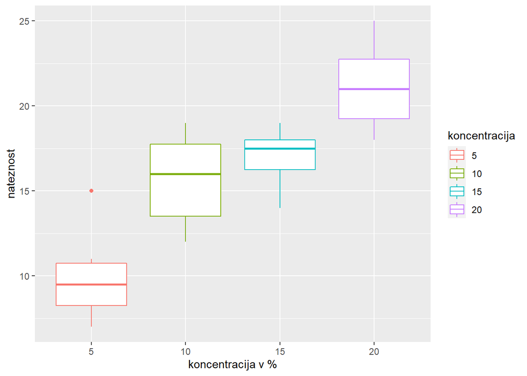

```r
ggplot(data = data8)+
  geom_boxplot(aes(x = koncentracija, y = nateznost, color = koncentracija))+
  xlab("koncentracija v %")
```

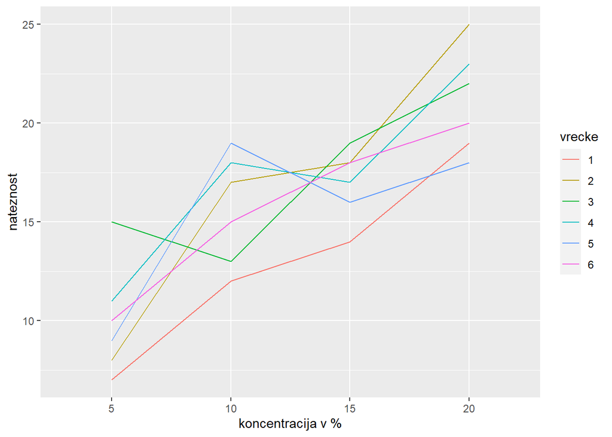

```r
ggplot(data8) +
  geom_line(aes(x=koncentracija, y=nateznost, color=vrecke, group = vrecke))+
  xlab("koncentracija v %")
```

Na podlagi grafov lahko ocenimo, da nateznost narasca s koncetracijo lesa, pride pa do izjem, ko določenim vrstam vreck pade nateznost, kljub višji koncentraciji.

### b.

```r
data.8 <- data8 %>% convert_as_factor(vrecke, koncentracija)
data.8$vrecke <- as.numeric(data.8$vrecke)
anova8 <- anova_test(data = data.8, dv = nateznost, wid = vrecke, within = koncentracija)
get_anova_table(anova8)
```

```
## ANOVA Table (type III tests)
##
##          Effect DFn DFd      F        p p<.05   ges
## 1 koncentracija   3  15 25.033 4.33e-06     * 0.746
```

p-vrednost modela je 4.33e-06, torej nivo koncentracije statisticno znacilno vpliva na natezno trdnost.

### c.

```r
pwc <- data.8 %>%
  pairwise_t_test(
    nateznost ~ koncentracija, paired = TRUE,
    p.adjust.method = "bonferroni"
    )
pwc
```

```
## # A tibble: 6 × 10
##   .y.       group1 group2    n1    n2 statistic    df       p p.adj p.adj.signif
## * <chr>     <chr>  <chr>  <int> <int>     <dbl> <dbl>   <dbl> <dbl> <chr>
## 1 nateznost 5      10         6     6     -3.25     5 2.3 e-2 0.137 ns
## 2 nateznost 5      15         6     6     -8.57     5 3.56e-4 0.002 **
## 3 nateznost 5      20         6     6     -7.97     5 5.01e-4 0.003 **
## 4 nateznost 10     15         6     6     -1.04     5 3.46e-1 1     ns
## 5 nateznost 10     20         6     6     -3.78     5 1.3 e-2 0.077 ns
## 6 nateznost 15     20         6     6     -4.78     5 5   e-3 0.03  *
```